# Classwork 12

Brandon Lo

2025-03-02

# Introduction

Link to Dataset: https://www.kaggle.com/datasets/kaggle/us-baby-names

### Description of my Dataset:

Name: Categorical  
Year: Quantitative Gender: Categorical State: Categorical Count: Quantitative

### Description of my Motivation:

My motivation for analyzing this dataset was because I was so fascinated on the popularity of names. I wanted to use that motivation to show my analysis on the popularity of names in a specfic group setting, such as this class. This was the perfect moment to show off my skills and interest in data analytics of this specific data set and I can’t be more proud of what I produced and what other projects I produce in the future.

# Visualizations

```r
library(dplyr)
```

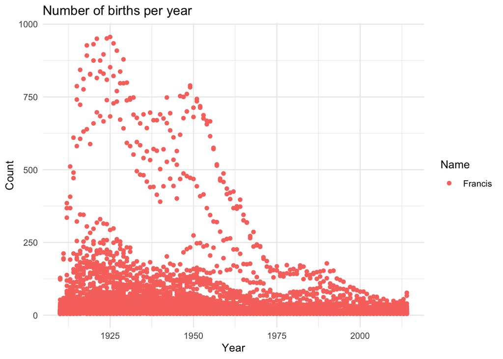

```r
library(ggplot2)

names <- read.csv("~/Downloads/COMP 162/StateNames.csv")

selected_names <- c("Francis")

subset <- names %>%
  filter(Name %in% selected_names)

# Create the faceted line graph with linear regression
ggplot(subset,
       aes(Year,
           Count,
           color = Name)) +
  geom_point() +  # Scatter plot for individual data points
  theme_minimal() +
  labs(title = "Number of births per year",
       x = "Year",
       y = "Count")
```

With this graph of a categorical and quantitative, it shows that male names had a more presence overall than females.

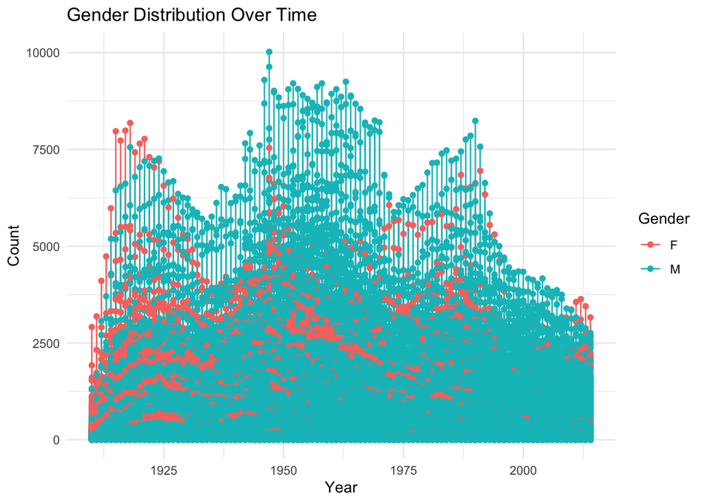

```r
ggplot(names,
       aes(
         Year,
         Count,
         color = Gender,
         group = Gender))+
  geom_line()+
  geom_point()+
  labs(title = "Gender Distribution Over Time",
       x = "Year",
       y = "Count",
       color = "Gender") +
  theme_minimal()
```

This is a bigger scale of name analysis in this dataset. As you can see, I’ve used 3 names and analyze their name popularity.

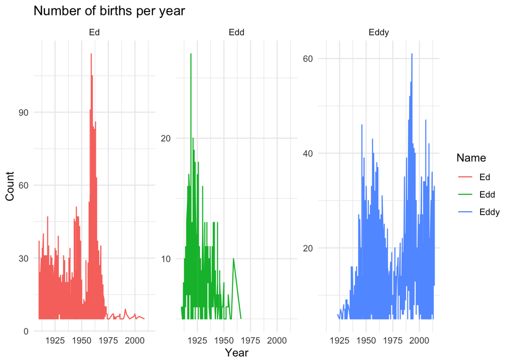

```r
#library(ggplot2)
#library(dplyr)
# Filter dataset for selected names
selected_names <- c("Ed", "Edd","Eddy")

subset <- names %>%
  filter(Name %in% selected_names)

# Create the faceted line graph
ggplot(subset,
       aes(Year,
           Count,
           color = Name)) +
  geom_line() +
  facet_wrap(~ Name, scales = "free_y") +  # Separate plots for each name
  theme_minimal() +
  labs(title = "Number of births per year",
       x = "Year",
       y = "Count")
```

# Dataset Maniipulations

Data manipulations can help narrow down the exact information you want from your dataset. For example, below shows 3 names specifically that I want to see the popularity name of.

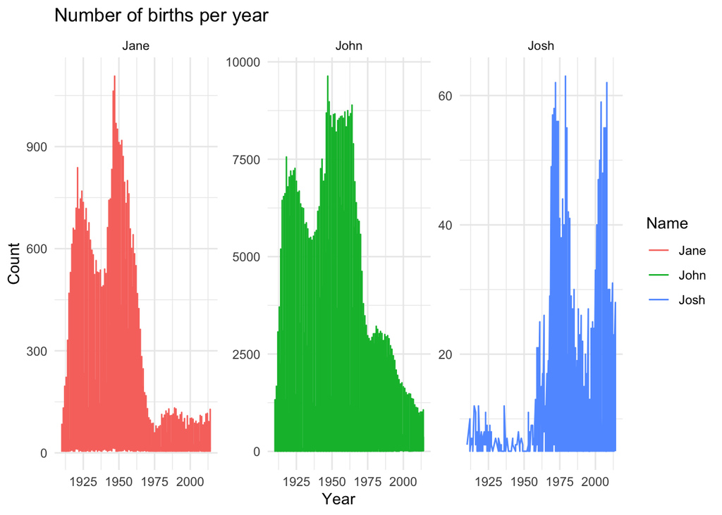

```r
# Filter dataset for selected names
selected_names <- c( "John", "Jane", "Josh")

subset <- names %>%
  filter(Name %in% selected_names)

# Create the faceted line graph
ggplot(subset,
       aes(Year,
           Count,
           color = Name)) +
  geom_line() +
  facet_wrap(~ Name, scales = "free_y") +  # Separate plots for each name
  theme_minimal() +
  labs(title = "Number of births per year",
       x = "Year",
       y = "Count")
```

# Statistical Analyses

```r
correlation <- cor(names$Year, names$Count)
correlation
```

```
## [1] -0.04643194
```

Visualization of the correlation of the variables year and count Linear Regression of the year and count columns. The linear regression line shows no vital information as it is just a straight line

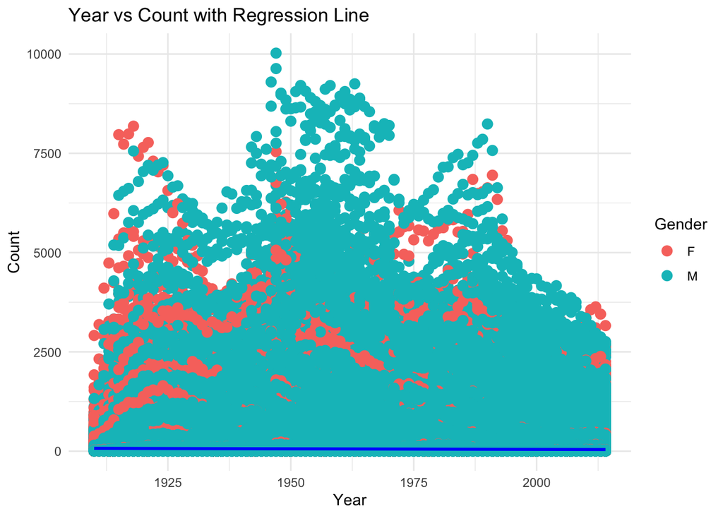

```r
# Scatter plot with regression line
ggplot(names,
       aes(Year,
           Count)) +
  geom_point(aes(color = Gender), size = 3) +
  geom_smooth(method = "lm", color = "blue", se = FALSE) +
  labs(title = "Year vs Count with Regression Line",
       x = "Year",
       y = "Count") +
  theme_minimal()
```

There is a highly significant difference between the names John and Jane. John’s mean count is much higher than Jane’s because of the means (Jane’s: 78.9 and John’s: 705.8).

```r
# Subset the data for two names (e.g., John and Jane)
subset_names <- subset %>%
  filter(Name %in% c("John", "Jane"))

# Perform a t-test to compare the counts between John and Jane
t_test_result <- t.test(Count ~ Name, data = subset_names)

# Output the t-test result
t_test_result
```

```
##
##  Welch Two Sample t-test
##
## data:  Count by Name
## t = -44.77, df = 7101.8, p-value < 2.2e-16
## alternative hypothesis: true difference in means between group Jane and group John is not equal to 0
## 95 percent confidence interval:
##  -654.3670 -599.4669
## sample estimates:
## mean in group Jane mean in group John
##           78.89719          705.81413
```

### How can you use this dataset to draw conclusions about a larger population?

To ensure my data is representing the purpose and population. Being able to perform appropriate statistical analysis. Getting good results and generalizing the findings within my dataset.

# Conclusion

Doing a large dataset in a project with statistical analysis was definitely a learning experience. I believe that my project write up still lives up to the expectations of my conclusions such as finding the popular names in this dataset and using data manipulation to help achieve that goal.